# Homework #3: Generalized Linear Regression

Jacob Norman  
2024-11-02

This is the third assignment for the course *ISE537: Statistical Models for Systems Analytics in Industrial Engineering*. The topic of this assignment is generalized linear regression, including:

- Concepts
- Fitting
- Inference
- Goodness of Fit
- Prediction

## Problem 1

### True/False/Multiple Choice

This section covers true or false and multiple choice questions concerning generalized linear regression, specifically logistic regression and poisson regression.

| **Q1** | **Q2** | **Q3** | **Q4** | **Q5** | **Q6** | **Q7** | **Q8** |
| --- | --- | --- | --- | --- | --- | --- | --- |
| T | F | T | T | F | F | F | F |
| **Q9** | **Q10** | **Q11** | **Q12** | **Q13** | **Q14** | **Q15** | **Q16** |
| F | F | F | T | T | T | F | T |
| **Q17** | **Q18** | **Q19** | **Q20** | **Q21** | **Q22** | **Q23** |  |
| F | C | C | C | A | D | A |  |

## Problem 2

This next section involves working through a generalized linear regression model from end-to-end, as we did previously with multiple regression. This time, we will be investigating employment data to determine whether employees will stay or leave a company. The supplied file includes the following columns:

- `Age Group`: Ranges from 1 to 9 and corresponds to age range in 10 year bins
- `Gender`: 1=Male, 0=Female
- `Tenure`: Number of years with the company
- `Num Of Products`: Number of products owned
- `Is Active Member`: 1=Active, 0=Inactive
- `Staying`: Fraction of employees that stayed with the company

Before we begin, let’s load the required packages for this analysis:

```r
#install.package("tidyverse")
library(tidyverse)
```

### Question 1. Fitting a Model

Next, let’s read in our data as a `tibble`:

```r
# read in data as tibble
data <- read_csv("data/hw4_data.csv")
# create new column for response variable
data$Staying <- data$Stay / data$Employees

# display tibble sumary
summary(data)
```

```
   Age Group         Gender           Tenure       Num Of Products
 Min.   :2.000   Min.   :0.0000   Min.   : 0.000   Min.   :1.000
 1st Qu.:3.000   1st Qu.:0.0000   1st Qu.: 2.000   1st Qu.:1.000
 Median :3.000   Median :1.0000   Median : 5.000   Median :1.000
 Mean   :3.557   Mean   :0.5316   Mean   : 4.823   Mean   :1.329
 3rd Qu.:4.000   3rd Qu.:1.0000   3rd Qu.: 7.000   3rd Qu.:2.000
 Max.   :5.000   Max.   :1.0000   Max.   :10.000   Max.   :2.000
 Is Active Member      Stay          Employees        Staying
 Min.   :0.0000   Min.   : 0.000   Min.   :10.00   Min.   :0.0000
 1st Qu.:0.0000   1st Qu.: 3.000   1st Qu.:12.00   1st Qu.:0.2411
 Median :0.0000   Median : 7.000   Median :15.00   Median :0.4361
 Mean   :0.4494   Mean   : 7.867   Mean   :16.39   Mean   :0.4715
 3rd Qu.:1.0000   3rd Qu.:11.000   3rd Qu.:20.00   3rd Qu.:0.7116
 Max.   :1.0000   Max.   :31.000   Max.   :35.00   Max.   :1.0000
```

We will now train a logistic regression model to predict `Staying` based on `Num Of Products`. This will be our initial model.

```r
model1 <- glm(Staying ~ `Num Of Products`, binomial, data, weights = Employees)
b1 <- coef(model1)[2]
summary(model1)
```

```
Call:
glm(formula = Staying ~ `Num Of Products`, family = binomial,
    data = data, weights = Employees)

Coefficients:
                  Estimate Std. Error z value Pr(>|z|)
(Intercept)         2.1457     0.1318   16.27   <2e-16 ***
`Num Of Products`  -1.7668     0.1031  -17.13   <2e-16 ***
---
Signif. codes:  0 '***' 0.001 '**' 0.01 '*' 0.05 '.' 0.1 ' ' 1

(Dispersion parameter for binomial family taken to be 1)

    Null deviance: 981.04  on 157  degrees of freedom
Residual deviance: 632.04  on 156  degrees of freedom
AIC: 1056.8

Number of Fisher Scoring iterations: 4
```

The parameters of the model are:

- $\hat\beta_0$, which corresponds to the `Intercept` and has an estimated value of 2.1457
- $\hat\beta_1$, which corresponds to `Num Of Products` and has an estimated value of -1.7668

The equation for the odds of staying is:

$$\frac{p}{1-p}=\exp(2.1457-1.7668x_\text{Num Of Products})$$

The estimated coefficient for `Num Of Products` can be interpreted in either of the following ways:

- **Log-Odds:** The log of the odds of staying decrease by 1.7668 for each additional product the employee owns.
- **Odds:** The odds of staying increase by 0.1709 for each additional product the employee owns.

### Question 2. Inference

Now let’s test run a 90% confidence interval for $\hat\beta_1$.

```r
confint(model1, level = 0.9)
```

```
                        5 %      95 %
(Intercept)        1.930071  2.363889
`Num Of Products` -1.938361 -1.598965
```

```r
# get test stat and df
gstat <- model1$null.deviance - deviance(model1)
df <- length(coef(model1)) - 1

# get p-value
p_value <- 1 - pchisq(gstat, df)
print(p_value)
```

```
[1] 0
```

Since the p-value of the overall regression is approximately equal to zero, `model1` is significant overall.

> **Note:** Question 2c is the same as Question 1c. See above for the answer.

### Question 3. Goodness of Fit

```r
# determine df
df1 <- nrow(data) - length(coef(model1))

# calculate deviance and pearson residuals
deviance1 <- residuals(model1, "deviance")
pearson1 <- residuals(model1, "pearson")

# calculate test statistic
dev1_tval <- sum(deviance1^2)
pear1_tval <- sum(pearson1^2)

# calculate p-value
dev1_pval <- 1 - pchisq(dev1_tval, df1)
pear1_pval <- 1 - pchisq(pear1_tval, df1)

# display output in tibble
tibble(Type = c("Deviance", "Pearson"),
       `Test Stat` = c(dev1_tval, pear1_tval),
       `p-value` = c(dev1_pval, pear1_pval))
```

```
# A tibble: 2 × 3
  Type     `Test Stat` `p-value`
  <chr>          <dbl>     <dbl>
1 Deviance        632.         0
2 Pearson         562.         0
```

For both the deviance and pearson residuals, we reject the null hypothesis that the logistic regression model fits the data well since both p-values are near zero. This contradicts what we found in the previous question when we determined that the overall model is significant.

Let’s investigate the deviance residuals visually to check goodness of fit and model assumptions.

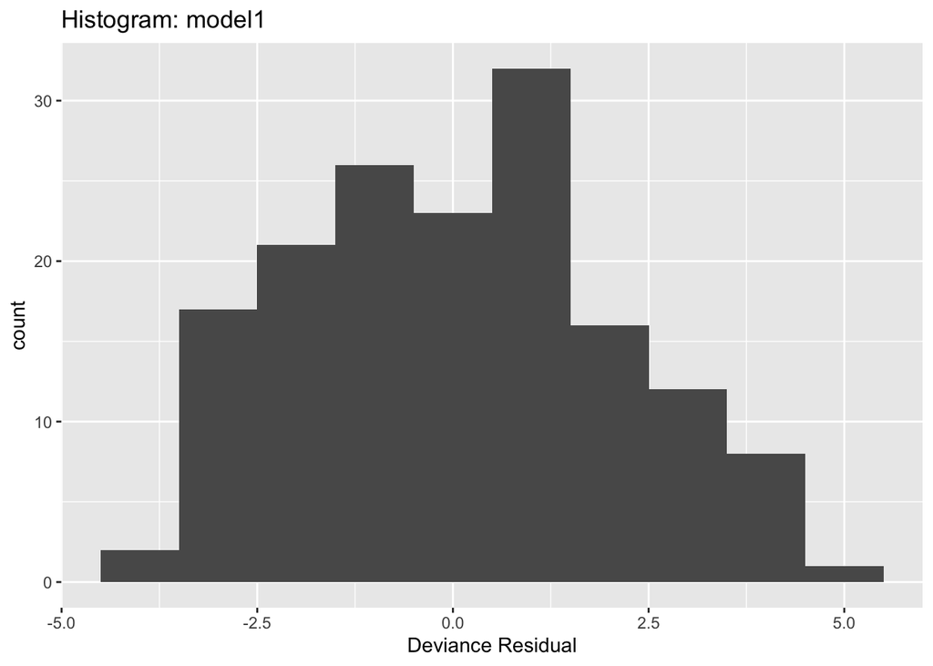

```r
ggplot() +
  geom_histogram(aes(deviance1), bins = 10) +
  labs(title = "Histogram: model1",
       x = "Deviance Residual")
```

The histogram of the deviance residuals appears somewhat normal. The plot seems to be centered on zero and has a vague bell shape. We can investigate further with a QQ-Plot:

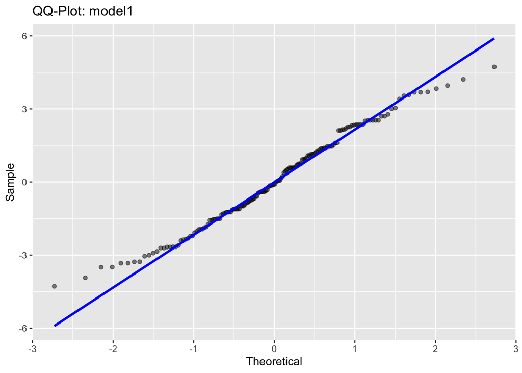

```r
ggplot(mapping = aes(sample = deviance1)) +
  stat_qq(alpha = 0.5) +
  stat_qq_line(color = "blue", linewidth = 1.1) +
  labs(title = "QQ-Plot: model1", x = "Theoretical", y = "Sample")
```

The QQ-Plot confirms that the deviance residuals are approximately normally distributed. The tail ends deviate from normality slightly, which makes sense given our histogram.

Let’s also check the linearity assumption. We would expect `Num Of Products` to be linear with respect to the log of the odds of `Staying`.

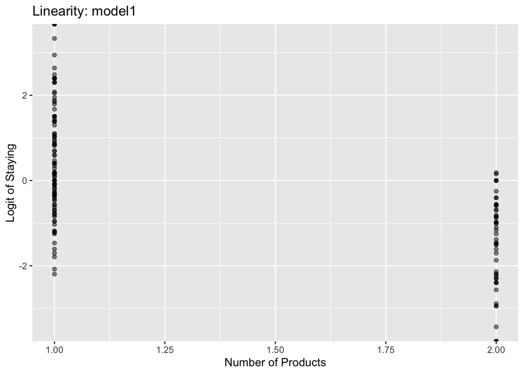

```r
data$logit_staying <- log(data$`Staying` / (1 - data$`Staying`))

ggplot(data) +
  geom_point(aes(`Num Of Products`, logit_staying), alpha=0.5) +
  labs(title = "Linearity: model1",
       x = 'Number of Products', y = "Logit of Staying")
```

It is difficult to assess this assumption since there are only two observed values for the `Num Of Products`: 1 or 2. Since it is only two points, of course we can say it is linear.

Next, we will determine if `model1` is overdispersed by estimating $\phi$:

```r
disp1<- dev1_tval / df1
disp1
```

```
[1] 4.051539
```

Since $\hat\phi>2$, we conclude that `model1` is overdispersed.

### Question 4. Fitting the Full Model

We will now expand our model to include all available predictors.

```r
model2 <- glm(Staying ~ `Age Group` + Gender + Tenure + `Num Of Products` + `Is Active Member`,
              binomial, data, weights = Employees)
summary(model2)
```

```
Call:
glm(formula = Staying ~ `Age Group` + Gender + Tenure + `Num Of Products` +
    `Is Active Member`, family = binomial, data = data, weights = Employees)

Coefficients:
                    Estimate Std. Error z value Pr(>|z|)
(Intercept)        -1.903330   0.330549  -5.758 8.51e-09 ***
`Age Group`         1.229014   0.075158  16.352  < 2e-16 ***
Gender             -0.551438   0.093139  -5.921 3.21e-09 ***
Tenure             -0.003574   0.016470  -0.217    0.828
`Num Of Products`  -1.428767   0.111181 -12.851  < 2e-16 ***
`Is Active Member` -0.871460   0.095034  -9.170  < 2e-16 ***
---
Signif. codes:  0 '***' 0.001 '**' 0.01 '*' 0.05 '.' 0.1 ' ' 1

(Dispersion parameter for binomial family taken to be 1)

    Null deviance: 981.04  on 157  degrees of freedom
Residual deviance: 171.94  on 152  degrees of freedom
AIC: 604.66

Number of Fisher Scoring iterations: 4
```

Based on `model2`, the equation for the probability of staying is:

$$p=\frac{\exp(-1.9033 + 1.2290x_\text{Age} - 0.5514x_\text{Gender} - 0.0036x_\text{Tenure} - 1.4288x_\text{Num Of Products} - 0.8715x_\text{Is Active Member}))}
{1 + \exp(-1.9033 + 1.2290x_\text{Age} - 0.5514x_\text{Gender} - 0.0036x_\text{Tenure} - 1.4288x_\text{Num Of Products} - 0.8715x_\text{Is Active Member}))}$$

Here are meaningful interpretations of two model coefficients:

- $\hat\beta_1$, `Age Group`: The odds of staying increases by 3.4179 for every 10 years of age an employee has, all other predictors held constant.
- $\hat\beta_5$, `Is Active Member`: The odds of staying increases by 0.4183 if an employee is an active member versus if they are an inactive member, all other predictors held constant.

The p-value for $\hat\beta_5$, `Is Active Member`, is near zero, which means that it is significant given the other variables in `model2`.

We will now repeat the goodness of fit analysis that we performed on `model1` for the full model, starting with the hypothesis test for the deviance and pearson residuals.

```r
# determine df
df2 <- nrow(data) - length(coef(model2))

# calculate deviance and pearson residuals
deviance2 <- residuals(model2, "deviance")
pearson2 <- residuals(model2, "pearson")

# calculate test statistic
dev2_tval <- sum(deviance2^2)
pear2_tval <- sum(pearson2^2)

# calculate p-value
dev2_pval <- 1 - pchisq(dev2_tval, df2)
pear2_pval <- 1 - pchisq(pear2_tval, df2)

# display output in tibble
tibble(Type = c("Deviance", "Pearson"),
       `Test Stat` = c(dev2_tval, pear2_tval),
       `p-value` = c(dev2_pval, pear2_pval))
```

```
# A tibble: 2 × 3
  Type     `Test Stat` `p-value`
  <chr>          <dbl>     <dbl>
1 Deviance        172.     0.128
2 Pearson         166.     0.201
```

We can see that the p-values under both residuals are now greater than a significance level of $\alpha=0.05$, meaning that we fail to reject the null hypothesis and conclude that `model2` is a good fit. Let’s us continue our investigation with a visual analysis.

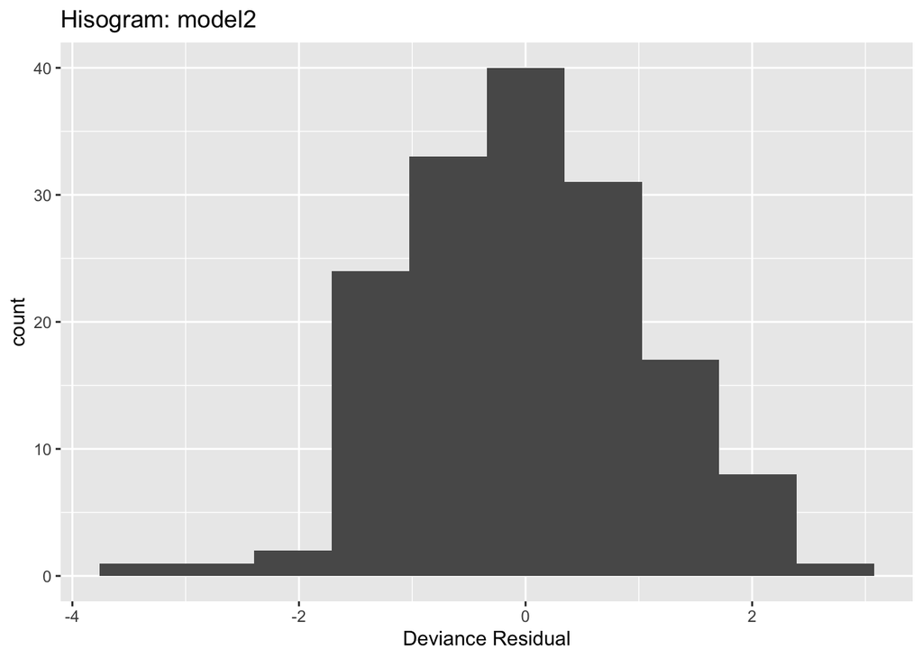

```r
ggplot() +
  geom_histogram(aes(deviance2), bins = 10) +
  labs(title = "Hisogram: model2",
       x = "Deviance Residual")
```

Similarly to the histogram for `model1`, we can see that deviance residuals appear approximately normally distributed. The left tail is not as “full” as we would expect, but there is a bell shape and they are centered at zero.

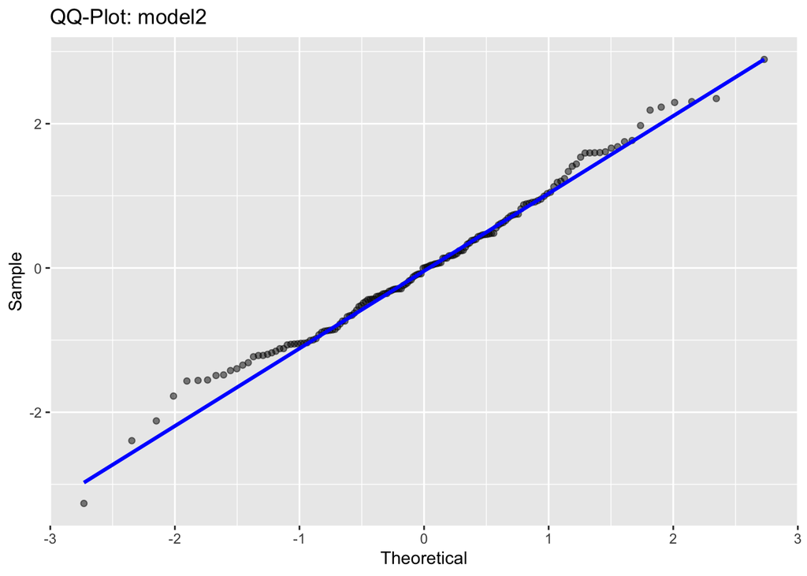

```r
ggplot(mapping = aes(sample = deviance2)) +
  stat_qq(alpha = 0.5) +
  stat_qq_line(color = "blue", linewidth = 1.1) +
  labs(title = "QQ-Plot: model2", x = "Theoretical", y = "Sample")
```

This QQ-Plot looks even better than what we saw with `model1`. The extreme values are closer to the blue line, indicating that `model2` is more normal than `model1`. The normality assumption holds.

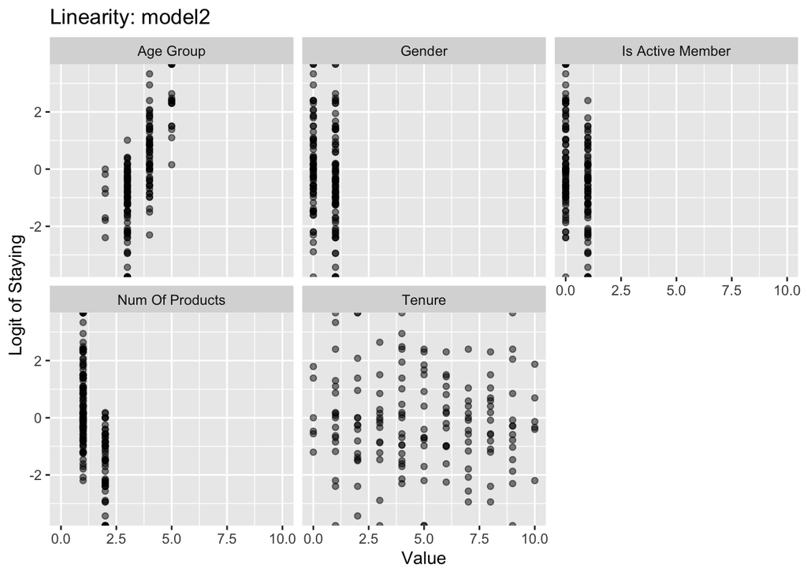

```r
# list of quantitiative predictors
predictors <- c("Age Group", "Gender", "Tenure",
                "Num Of Products", "Is Active Member")

# convert data from wide to long format in order to facet
data_melted <- data %>%
                  select(-c(Stay, Employees, Staying)) %>%
                  pivot_longer(cols = all_of(predictors),
                               names_to = "Measure",
                               values_to = "Value"
                  )

# create plot
ggplot(data_melted) +
  geom_point(aes(Value, logit_staying), alpha=0.5) +
  facet_wrap(~ Measure) +
  labs(title = "Linearity: model2", y = "Logit of Staying")
```

The linearity assumption is still difficult to properly assess for the same reasons we noted with `model1`. There do not seem to be any obvious problems with the relationship between the logit of staying and any of the predictors. Perhaps there is a higher order relationship with `Age Group`, but it is hard to be definitive. Overall, we can say the linearity assumption holds.

Moving on, let’s calculate the estimated dispersion parameter, $\hat\phi$, for `model2`:

```r
disp2<- dev2_tval / df2
disp2
```

```
[1] 1.131172
```

Since $\hat\phi < 2$, we can conclude that the full model is *not* overdispersed.

### Question 5. Prediction

Suppose that there is an employee with the following characteristics:

- `Age Group` = 2
- `Gender` = 0
- `Tenure` = 2
- `Num Of Products` = 2
- `Is Active Member` = 1

Let’s predict their probability of staying under both models:

```r
# create tibble of test data
test <- tibble(`Age Group` = 2,
               Gender = 0,
               Tenure = 2,
               `Num Of Products` = 2,
               `Is Active Member` = 1)

# generate predicted probablities
pred1 <- predict(model1, test, type = "response")
pred2 <- predict(model2, test, type = "response")

# display results in tibble
tibble(Model = c("model1", "model2"),
       Probablity = c(pred1, pred2))
```

```
# A tibble: 2 × 2
  Model  Probablity
  <chr>       <dbl>
1 model1     0.200
2 model2     0.0399
```

It seems that `model1` predicts that an employee with the above traits has a 20 percent chance of staying, while `model2` predicts only a 4 percent chance of staying. Again, `model1` is only considering `Num of Products` while `model2` is considering all of the characteristics. We determined that the full model is a better fit to our data and thus should be more confident in the prediction of the employee under this model.